# Exercise Set 8

**Instructions:**

- Do not write your name on the assignment. Be careful about any warnings that might display some file path with your name included.
- Receiving help from classmates and/or ideas from Generative AI is allowed. **However, you must submit your own original work.**
- For questions that require coding, you need to write the relevant code and display its output. Your output should either be the direct answer to the question or clearly display the answer in it.
- For questions that require a written answer (sometimes along with the code), you need to put your answer in a Markdown cell. Writing the answer as a comment or as a print line is not acceptable.
- You need to render this file as HTML using Quarto and submit the HTML file. **Please note that this is a requirement and not optional.** A submission cannot be graded until it is properly rendered.

Import all the libraries and tools you need below.

```python
import warnings
warnings.filterwarnings('ignore')

import matplotlib.pyplot as plt
from IPython.display import clear_output
from sklearn.datasets import make_blobs, make_circles
import pandas as pd
import numpy as np
from sklearn.cluster import DBSCAN, KMeans
# %pip install scikit-learn-extra
from sklearn_extra.cluster import KMedoids
```

Run the cell given below to create and plot the same two toy datasets from the previous exercise set.

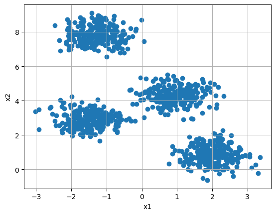

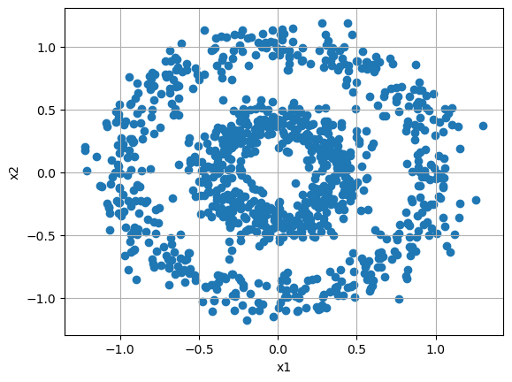

```python
n_samples = 1000
n_components = 4

X_blob, true_labels_blob = make_blobs(n_samples=n_samples, centers=4, cluster_std=0.50, random_state=0)
X_circ, true_labels_circ = make_circles(n_samples=n_samples, noise=0.1, random_state=0,factor=0.4)

plt.scatter(X_blob[:,0],X_blob[:,1])
plt.grid()
plt.xlabel('x1')
plt.ylabel('x2')
plt.show()

plt.scatter(X_circ[:,0],X_circ[:,1])
plt.grid()
plt.xlabel('x1')
plt.ylabel('x2')
plt.show()
```

## 1)

Copy the `assignment_step` and `update_step` functions you wrote in the previous exercise set here. **(1 point)**

```python
def update_step(X, cluster_preds):
    df = pd.DataFrame(np.column_stack((X, cluster_preds)))
    centroids = df.groupby(X.shape[1]).mean()
    return centroids.to_numpy()

def assignment_step(X, centroids):
    distances = np.linalg.norm(X[:, None, :] - centroids[None, :, :], axis=2)
    return np.argmin(distances, axis=1)
```

## 2)

Define a function called `lloyds_algorithm`. It should take three inputs: (1) `X`, the variable matrix, (2) `num_clusters`, the number of clusters the algorithm finds, and (3) `random_state`, a random seed for reproducibility.

The function should:

- Create a [random seed](https://numpy.org/doc/stable/reference/random/generated/numpy.random.seed.html) with the input `random_state`.
- [Initialize](https://numpy.org/doc/stable/reference/random/generated/numpy.random.randint.html) a vector of random cluster labels. Note that each observation in `X` should have a label.
- Run Lloyd’s algorithm by alternating between the `M_step` and the `E_step` until convergence, which means the labels no longer change.
- Create a color-coded scatter plot of the clustered data (`X`) in each iteration.
- Return the predicted cluster labels and centroids.

**Note:** If you use Jupyter, you can use `clear_output(wait=True)` at the top of your visualization lines to make your consecutive figures replace each other, which would visualize the convergence better. If you do not use Jupyter, you can either find another way or simply plot multiple figures. **(This is not mandatory.)**

**(34 points)**

```python
def lloyds_algorithm(X, num_clusters, random_state):

    np.random.seed(random_state)
    labels = np.random.randint(0, num_clusters, size=X.shape[0])

    while True:
        centroids = update_step(X, labels)

        new_labels = assignment_step(X, centroids)

        plt.scatter(X[:, 0], X[:, 1], c=new_labels, cmap='viridis')
        plt.scatter(centroids[:, 0], centroids[:, 1], c='red', marker='X', s=200)
        plt.xlabel('x1')
        plt.ylabel('x2')
        plt.grid()
        plt.show()

        if np.array_equal(labels, new_labels):
            break

        labels = new_labels

    centroids = update_step(X, new_labels)

    return new_labels, centroids
```

## 3)

Run the `lloyds_algorithm` function with the two toy datasets and their proper number of clusters. You should see the correct clusters in one dataset and incorrect clusters in the other.

Find a `random_state` that works (for the dataset that should return the correct clusters). Note that not every `random_state` will work, because random initialization of the assigned cluster labels is not the most robust way to start Lloyd’s algorithm for a K-Means model. This is fine for the purposes of this exercise set; as discussed in lecture, scikit-learn has different ways to initialize the model.

Lastly, explain why the algorithm (and the K-Means model it trains) does not work well with the dataset that ended up having incorrect clusters. Make sure you include the relevant assumption of a K-Means model in your explanation.

**(5 points)**

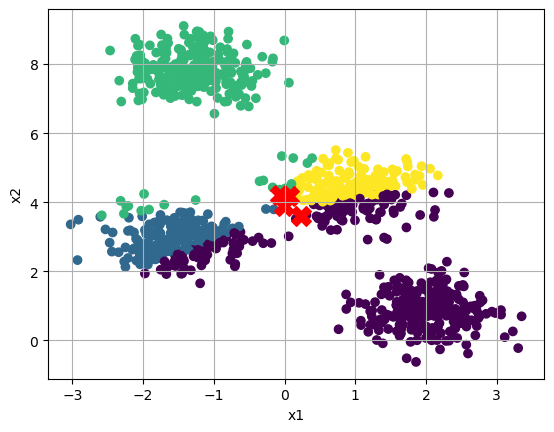

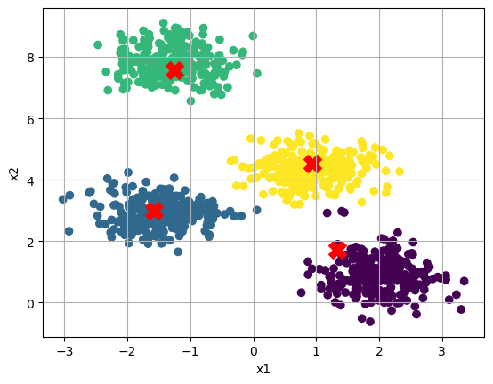

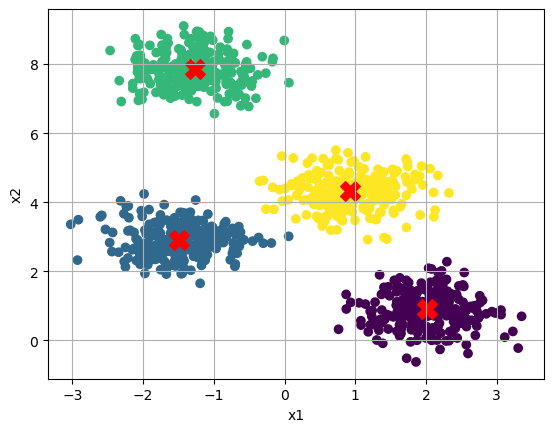

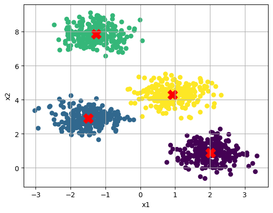

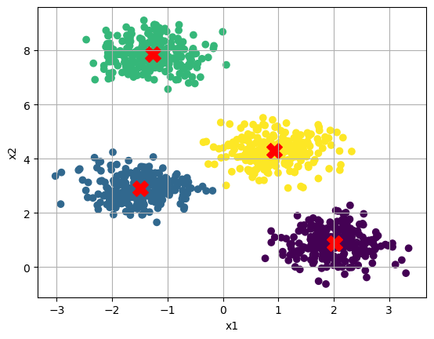

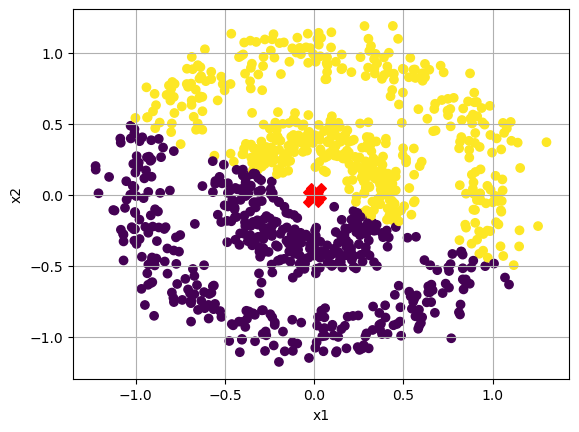

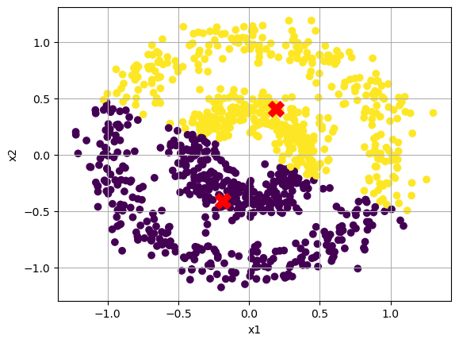

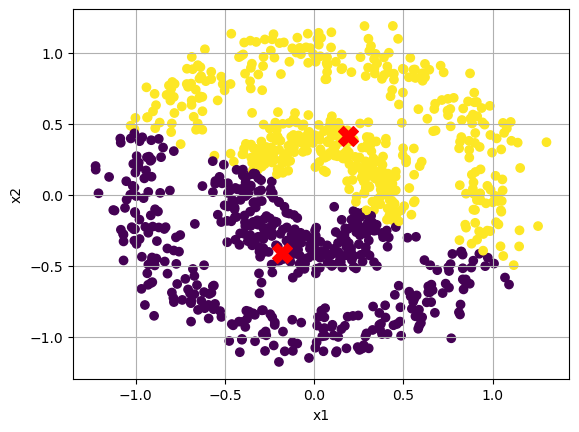

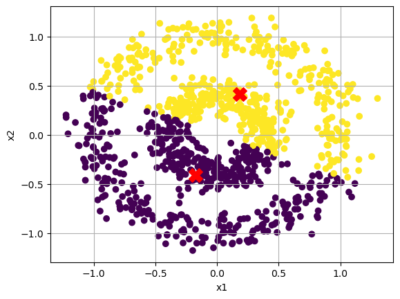

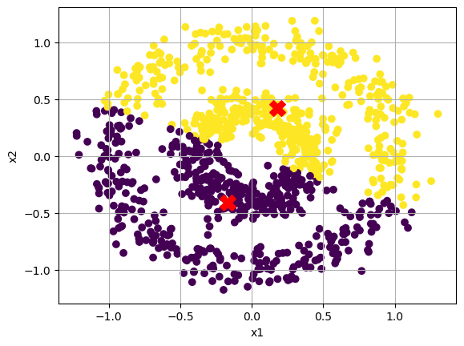

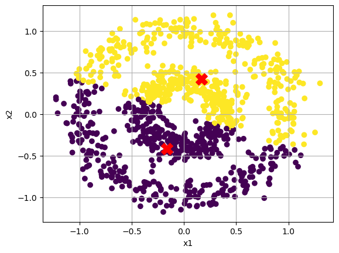

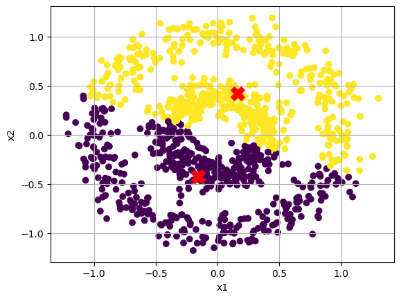

[13 more figures not shown]

```python
labels_blob, centroids_blob = lloyds_algorithm(X_blob, 4, 2)

labels_circ, centroids_circ = lloyds_algorithm(X_circ, 2, 2)
```

Lloyd’s algorithm works well for the blobs dataset, but it can not get the cirle one. K-Means assumes clusters are sort of “spherical” and centered around their means. With the blobs, this works because they follow this asumption, but the circles has one cluster surrounding the other one so it does not separate them correctly. K-Means assigns points based on their distance to the centroids, so it can’t properly separate the inner and outer circles.

## 4)

### a)

Create a [DB-SCAN](https://scikit-learn.org/dev/modules/generated/sklearn.cluster.DBSCAN.html) model to cluster the dataset for which the K-Means model did not work. Find an `eps` input that performs well and leave everything else as default. Visualize the clustered dataset with a color-coded scatter plot to see how DB-SCAN performs.

Besides the correct clusters on the figure, what else do you see that was not produced with the K-Means model and the EM algorithm?

**(15 points)**

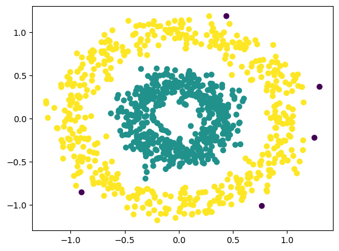

```python
dbscan = DBSCAN(eps=0.14)
labels = dbscan.fit_predict(X_circ)

plt.scatter(X_circ[:, 0], X_circ[:, 1], c=labels)
plt.show()
```

Besides the 2 clusters correctly identified, the DB-SCAN model also identifies noise (which are the purple points). The points don’t belong to either cluster, unlike K-Means and EM which assign every point to a cluster.

### b)

Repeat Part a twice: Once with `eps=0.1` and a second time with `eps=0.15`. (Both repetitions should be maintained in the code and the output.) What happens to the clusters with such small changes? What does this say about the DB-SCAN model? **(15 points)**

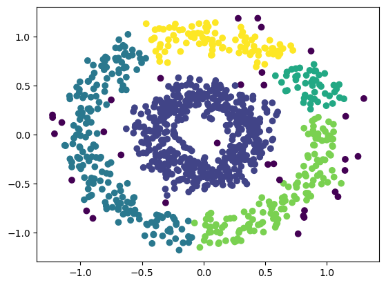

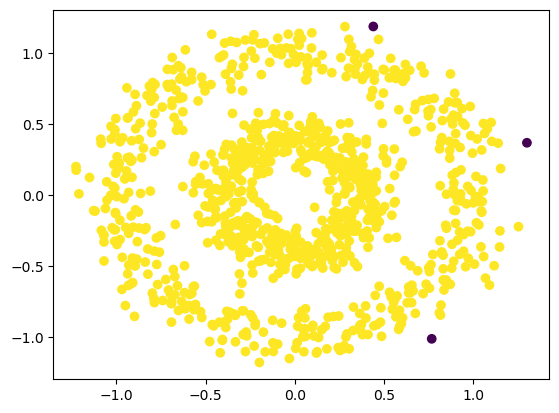

```python
dbscan = DBSCAN(eps=0.1)
labels = dbscan.fit_predict(X_circ)

plt.scatter(X_circ[:, 0], X_circ[:, 1], c=labels)
plt.show()

dbscan = DBSCAN(eps=0.15)
labels = dbscan.fit_predict(X_circ)

plt.scatter(X_circ[:, 0], X_circ[:, 1], c=labels)
plt.show()
```

When we decrease the eps to .1, the DBSCAN splits the outer circle into a lot of multiple clusters and identifies a large amount of points as noise. However, when eps is 0.15, it makes both circles into one single cluster with only 3 noise points. This indicates that DBSCAN is very sensitive to the choice of eps, because a small change can complitely change the results.

## 5)

Run the cell given below to create and plot a dataset with visible clusters and many outliers.

```python
n_samples = 300
n_outliers = 20

X, y = make_blobs(n_samples=n_samples, centers=3, cluster_std=0.8, random_state=12)
outliers = np.random.uniform(low=-15, high=15, size=(n_outliers, 2))
X_out = np.vstack([X, outliers])
y_out = np.concatenate([y, [-1] * n_outliers])
```

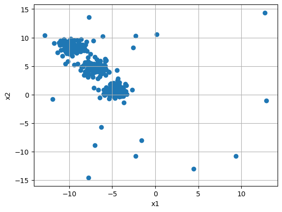

```python
plt.scatter(X_out[:,0],X_out[:,1])
plt.grid()
plt.xlabel('x1')
plt.ylabel('x2')
plt.show()
```

### a)

Cluster the data using a K-Means model from the scikit-learn library and the proper number of clusters. Use every `random_state` from 1 to 5. For each `random_state`, plot (1) the dataset, color-coded with predicted cluster labels, and (2) the centroids. (You should produce 5 figures in total.)

What do you observe about the clusters in the figures? What does that tell you about K-Means and outliers?

**(15 points)**

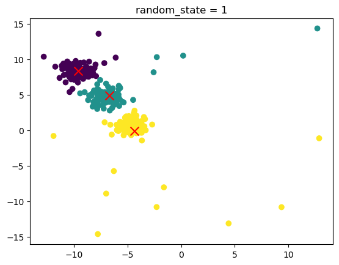

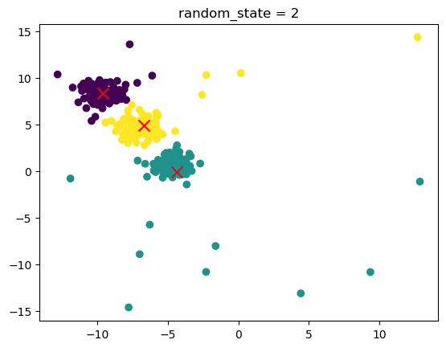

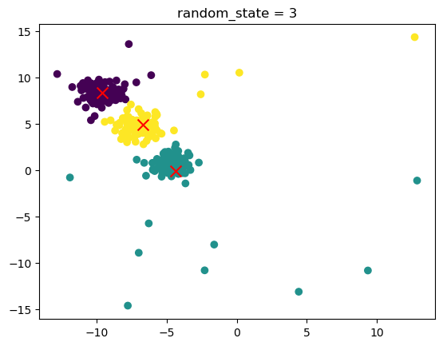

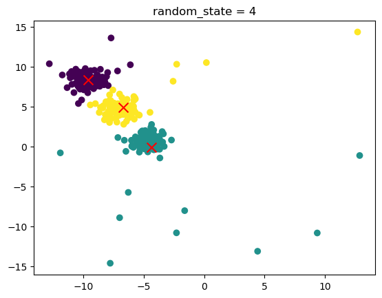

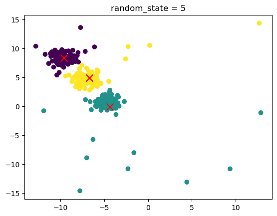

```python
for i in range(1, 6):
    model = KMeans(n_clusters=3, random_state=i)
    labels = model.fit_predict(X_out)

    plt.scatter(X_out[:, 0], X_out[:, 1], c=labels)
    plt.scatter(model.cluster_centers_[:, 0], model.cluster_centers_[:, 1], c='red', marker='x', s=100)
    plt.title(f'random_state = {i}')
    plt.show()
```

The results change a little bit based on the random state. But even though there are three clear clusters, some centroids get pulled away from them because of the outliers. This shows that K-Means very is sensitive to outliers because it uses the mean to calculate the centroids, and points that are far away affect the averages.

### b)

Repeat Part a with a [K-Medoids](https://scikit-learn-extra.readthedocs.io/en/stable/generated/sklearn_extra.cluster.KMedoids.html) model. How are the 5 figures you produced in this part different than the ones produced in Part a? Explain how the K-Medoids model creates this difference by comparing the algorithms that train K-Means and K-Medoids models.

**Note:** You will need to install the **scikit-learn-extra** library for this question.

**(15 points)**

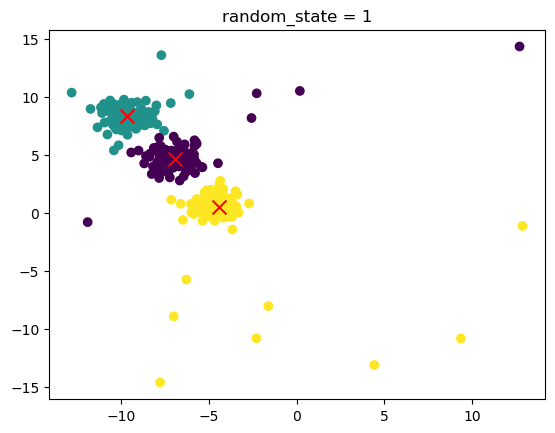

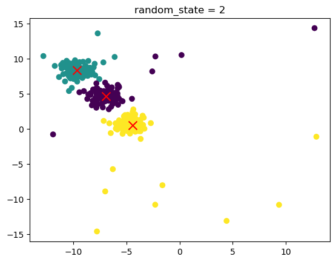

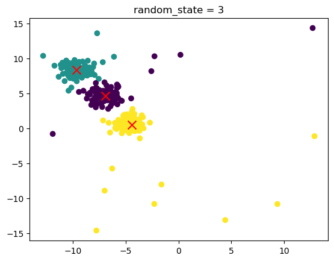

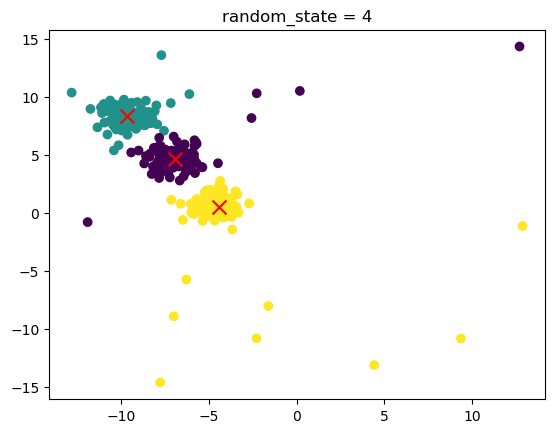

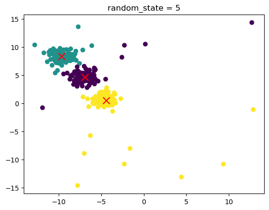

```python
for i in range(1, 6):
    model = KMedoids(n_clusters=3, random_state=i)
    labels = model.fit_predict(X_out)

    plt.scatter(X_out[:, 0], X_out[:, 1], c=labels)
    plt.scatter(model.cluster_centers_[:, 0], model.cluster_centers_[:, 1],
                c='red', marker='x', s=100)
    plt.title(f'random_state = {i}')
    plt.show()
```

K-Medoids results are more consistent across the five random states, and the centers stay closer to the three main clusters compared to K-Means. Because K-Means updates the centroids by taking the mean of the points in each cluster, outliers can pull the centroids away. K-Medoids uses actual data points as centers and minimizes the total distance between points and their medoids, making it less sensitive to outliers.